# Análise da Dinâmica do Pêndulo de Ondas

Este projeto explora a modelagem matemática e a validação experimental de um sistema de pêndulos simples sob a influência de forças de arrasto. O objetivo é compreender como variações no comprimento do fio impactam o período de oscilação e o alcance vertical, comparando simulações numéricas com dados reais obtidos via rastreamento de vídeo (Tracker).

## 1. Configuração do Ambiente e Importações

Utilizamos uma estrutura modular para manter o código limpo. Toda a lógica física e de utilitários foi movida para o diretório `src/`.

```python
import sys
import os
import numpy as np
import matplotlib.pyplot as plt
import pandas as pd

# Adiciona o diretório src ao path para importação
sys.path.append(os.path.abspath('../src'))

from physics import PendulumSimulator
from data_utils import load_experimental_data, get_simulation_parameters

# Configuração estética dos gráficos
plt.style.use('seaborn-v0_8-whitegrid')
plt.rcParams['figure.figsize'] = (10, 6)
plt.rcParams['axes.titlesize'] = 14
plt.rcParams['axes.labelsize'] = 12
```

## 2. Modelagem Física e Simulação

O modelo considera a segunda lei de Newton aplicada ao pêndulo, incluindo a força peso, a tração no fio e a força de arrasto do ar ($F_a = \frac{1}{2} \rho A C_d v^2$).

```python
# Instancia o simulador com parâmetros físicos padrão
params = get_simulation_parameters()
sim = PendulumSimulator(g=params['g'], rho=params['rho'])

# Configuração da simulação base
L = 0.24  # Comprimento do fio (m)
t_lista = np.arange(0, 5, 1e-3)
initial_state = [-L, 0, 0, 0]  # x0, y0, vx0, vy0

# Executa a simulação
results = sim.simulate(L, params['m'], params['r'], initial_state, t_lista)
x_lista, y_lista = results[:, 0], results[:, 1]
```

## 3. Validação Experimental

Comparamos os resultados do modelo numérico com os dados coletados experimentalmente.

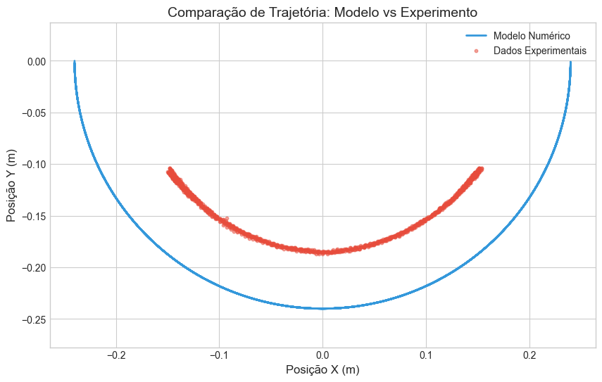

```python
# Carrega dados experimentais ajustados
dados_exp = load_experimental_data('../data/experimento.csv')

# Plot de comparação de trajetória
plt.figure()
plt.plot(x_lista, y_lista, label='Modelo Numérico', color='#3498db', linewidth=2)
plt.scatter(dados_exp['x'], dados_exp['y'], label='Dados Experimentais', color='#e74c3c', s=10, alpha=0.5)
plt.title("Comparação de Trajetória: Modelo vs Experimento")
plt.xlabel("Posição X (m)")
plt.ylabel("Posição Y (m)")
plt.legend()
plt.axis('equal')
plt.show()
```

## 4. Análise Paramétrica: Comprimento vs Período

Nesta seção, simulamos uma série de pêndulos com diferentes comprimentos para observar a formação do padrão de ondas.

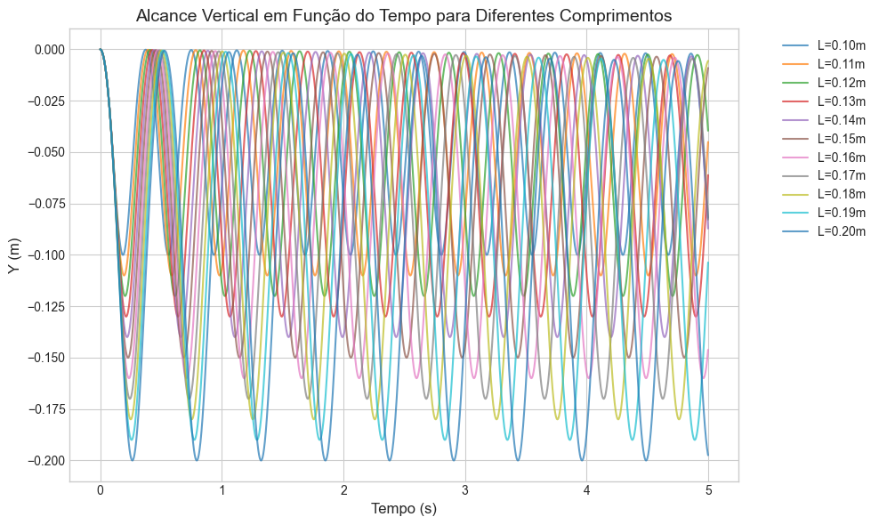

```python
comprimentos = np.linspace(0.10, 0.20, 11)
periodos = []
alturas_max = []

plt.figure()
for L in comprimentos:
    res = sim.simulate(L, params['m'], params['r'], [-L, 0, 0, 0], t_lista)
    y_sim = res[:, 1]

    periodos.append(sim.calculate_period(y_sim, t_lista))
    alturas_max.append(sim.calculate_max_height(y_sim))

    plt.plot(t_lista, y_sim, label=f'L={L:.2f}m', alpha=0.7)

plt.title("Alcance Vertical em Função do Tempo para Diferentes Comprimentos")
plt.xlabel("Tempo (s)")
plt.ylabel("Y (m)")
plt.legend(bbox_to_anchor=(1.05, 1), loc='upper left')
plt.tight_layout()
plt.show()
```

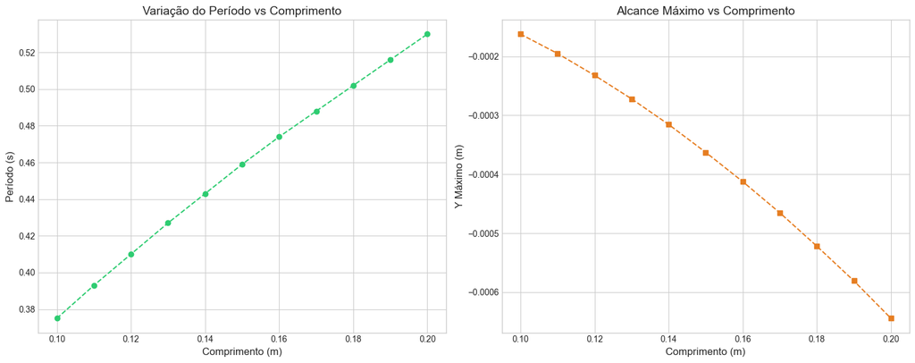

```python
fig, (ax1, ax2) = plt.subplots(1, 2, figsize=(15, 6))

ax1.plot(comprimentos, periodos, 'o--', color='#2ecc71')
ax1.set_title("Variação do Período vs Comprimento")
ax1.set_xlabel("Comprimento (m)")
ax1.set_ylabel("Período (s)")

ax2.plot(comprimentos, alturas_max, 's--', color='#e67e22')
ax2.set_title("Alcance Máximo vs Comprimento")
ax2.set_xlabel("Comprimento (m)")
ax2.set_ylabel("Y Máximo (m)")

plt.tight_layout()
plt.show()
```